# p6

## Clustering and NLP

```python
import numpy as np
import pandas as pd
import matplotlib.pyplot as plt
import hazm
import gensim
from gensim.models import Doc2Vec
from sklearn.cluster import KMeans
from sklearn.decomposition import PCA
from sklearn.metrics import homogeneity_score
from sklearn.metrics import silhouette_score
from sklearn.cluster import DBSCAN
```

### Load Data

```python
train_data = pd.read_csv ("train.csv")
test_data = pd.read_csv ("test.csv")
```

```python
train_text_data = train_data["content"]
test_text_data = test_data["content"]
```

```python
train_data_labels = train_data["label"].unique ()

train_data["label"].replace (train_data_labels, [0, 1, 2, 3, 4, 5], inplace = True)
```

```python
test_data_labels = test_data["label"].unique ()

test_data["label"].replace (test_data_labels, [0, 1, 2, 3, 4, 5], inplace = True)
```

```python
train_data_labels = train_data["label"]
test_data_labels = test_data["label"]
```

### Pre Processing

```python
normalizer = hazm.Normalizer ()
```

```python
lemmatizer = hazm.Lemmatizer ()
```

```python
for i in range (len (train_text_data)):
    train_text_data[i] = normalizer.normalize (train_text_data[i])
```

```
C:\Users\Mohammad Reza\AppData\Local\Temp\ipykernel_13660\3864901783.py:2: SettingWithCopyWarning:
A value is trying to be set on a copy of a slice from a DataFrame

See the caveats in the documentation: https://pandas.pydata.org/pandas-docs/stable/user_guide/indexing.html#returning-a-view-versus-a-copy
  train_text_data[i] = normalizer.normalize (train_text_data[i])
```

```python
for i in range (len (test_text_data)):
    test_text_data[i] = normalizer.normalize (test_text_data[i])
```

```
C:\Users\Mohammad Reza\AppData\Local\Temp\ipykernel_13660\4021050339.py:2: SettingWithCopyWarning:
A value is trying to be set on a copy of a slice from a DataFrame

See the caveats in the documentation: https://pandas.pydata.org/pandas-docs/stable/user_guide/indexing.html#returning-a-view-versus-a-copy
  test_text_data[i] = normalizer.normalize (test_text_data[i])
```

```python
train_text_word = []
stopwords = hazm.stopwords_list ()
punchs = ['.', '،', '؛', '؟', '!', ':']

for i in range (len (train_text_data)):
    words = []

    for w in hazm.word_tokenize (train_text_data[i]):
        if (w not in stopwords) and (w not in punchs):
            l = lemmatizer.lemmatize (w)
            w = l.split ("#")[0]
            words.append (w)

    train_text_word.append (words)
```

```python
test_text_word = []

for i in range (len (test_text_data)):
    words = []

    for w in hazm.word_tokenize (test_text_data[i]):
        if (w not in stopwords) and (w not in punchs):
            l = lemmatizer.lemmatize (w)
            w = l.split ("#")[0]
            words.append (w)

    test_text_word.append (words)
```

```python
label = gensim.models.doc2vec.TaggedDocument
```

```python
labeled_train_text = []

for i in range (len (train_text_word)):
    labeled_train_text.append (label (train_text_word[i], [i]))
```

### Create Doc2Vec Model

```python
model = Doc2Vec (labeled_train_text, window = 3, vector_size = 5)
model.train (labeled_train_text, total_examples = model.corpus_count, epochs = model.epochs)
```

### Find K for Train Set

```python
inertias1 = []

for k in range (1, 11):
    kmeans_model1 = KMeans (n_clusters = k)
    kmeans_model1.fit (model.docvecs.vectors)
    inertias1.append (kmeans_model1.inertia_)
```

[output not shown]

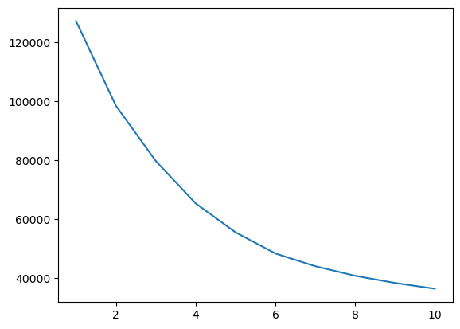

```python
k_values = list (range (1, 11))

plt.plot (k_values, inertias1)
plt.show ()
```

### K-Means Clustring for Train Set

```python
kmeans_model1 = KMeans (n_clusters = 6)
kmeans_model1.fit (model.docvecs.vectors)
predicted_labels1 = kmeans_model1.labels_.tolist()
```

```
C:\Users\Mohammad Reza\AppData\Local\Temp\ipykernel_13660\3759419674.py:2: DeprecationWarning: Call to deprecated `docvecs` (The `docvecs` property has been renamed `dv`.).
  kmeans_model1.fit (model.docvecs.vectors)
```

```python
l = kmeans_model1.fit_predict (model.docvecs.vectors)
pca = PCA (n_components = 2).fit (model.docvecs.vectors)
d = pca.transform (model.docvecs.vectors)
```

[output not shown]

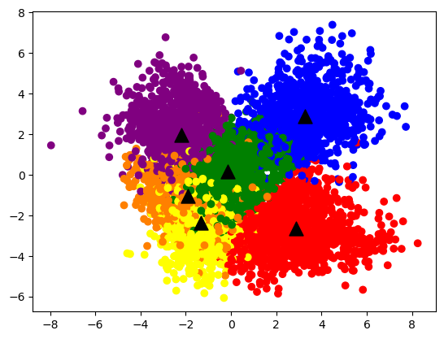

```python
%matplotlib inline
plt.figure
label1 = ["#FFFF00", "#008000", "#0000FF", "#800080", "#FF8000", "#FF0000"]
color = [label1[i] for i in predicted_labels1]
plt.scatter (d[:, 0], d[:, 1], c = color)
centroids = kmeans_model1.cluster_centers_
centroidpoint = pca.transform (centroids)
plt.scatter(centroidpoint[:, 0], centroidpoint[:, 1], marker='^', s=150, c='#000000')
plt.show ()
```

```python
homo_score1 = homogeneity_score (train_data_labels, predicted_labels1)
print (homo_score1)
```

```
0.4809050129187334
```

```python
sil_score1 = silhouette_score (model.docvecs.vectors, predicted_labels1)
print (sil_score1)
```

```
C:\Users\Mohammad Reza\AppData\Local\Temp\ipykernel_13660\2099887843.py:1: DeprecationWarning: Call to deprecated `docvecs` (The `docvecs` property has been renamed `dv`.).
  sil_score1 = silhouette_score (model.docvecs.vectors, predicted_labels1)
```

```
0.30993977
```

### DBSCAN Clustering for Train Set

```python
db1 = DBSCAN (eps = 1)
db1.fit (model.docvecs.vectors)
db_predicted_labels1 = db1.labels_
```

```
C:\Users\Mohammad Reza\AppData\Local\Temp\ipykernel_13660\902433661.py:2: DeprecationWarning: Call to deprecated `docvecs` (The `docvecs` property has been renamed `dv`.).
  db1.fit (model.docvecs.vectors)
```

```
C:\Users\Mohammad Reza\AppData\Local\Temp\ipykernel_13660\665827837.py:1: DeprecationWarning: Call to deprecated `docvecs` (The `docvecs` property has been renamed `dv`.).
  plt.scatter(model.docvecs.vectors[:,0], model.docvecs.vectors[:,1],c = db_predicted_labels1, cmap='Paired')
```

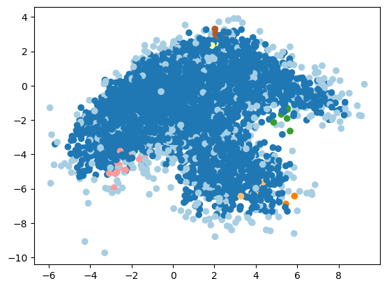

```python
plt.scatter(model.docvecs.vectors[:,0], model.docvecs.vectors[:,1],c = db_predicted_labels1, cmap='Paired')
plt.show ()
```

```python
homo_score1 = homogeneity_score (train_data_labels, db_predicted_labels1)
print (homo_score1)
```

```
0.012576833514204881
```

```python
sil_score1 = silhouette_score (model.docvecs.vectors, db_predicted_labels1)
print (sil_score1)
```

```
C:\Users\Mohammad Reza\AppData\Local\Temp\ipykernel_13660\1476330605.py:1: DeprecationWarning: Call to deprecated `docvecs` (The `docvecs` property has been renamed `dv`.).
  sil_score1 = silhouette_score (model.docvecs.vectors, db_predicted_labels1)
```

```
-0.047409326
```

### Find K for Test Set

```python
vectors = []

for i in range (len (test_text_word)):
    vector = model.infer_vector (test_text_word[i])
    vectors.append (vector)

vectors = np.array (vectors)
```

```python
inertias2 = []

for k in range (1, 11):
    kmeans_model2 = KMeans (n_clusters = k)
    kmeans_model2.fit (vectors)
    inertias2.append (kmeans_model2.inertia_)
```

[output not shown]

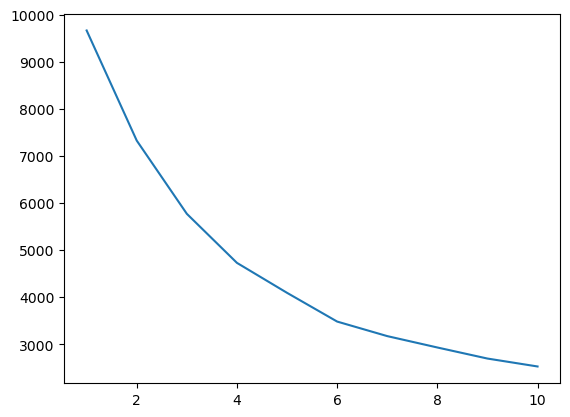

```python
k_values = list (range (1, 11))

plt.plot (k_values, inertias2)
plt.show ()
```

### K-Means Clustering for Test Set

```python
kmeans_model2 = KMeans (n_clusters = 6)
kmeans_model2.fit (vectors)
predicted_labels2 = kmeans_model2.labels_.tolist()
```

```python
l = kmeans_model2.fit_predict (vectors)
pca = PCA (n_components = 2).fit (vectors)
d = pca.transform (vectors)
```

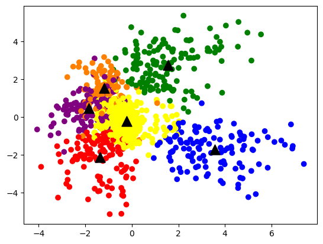

```python
%matplotlib inline
plt.figure
label1 = ["#FFFF00", "#008000", "#0000FF", "#800080", "#FF8000", "#FF0000"]
color = [label1[i] for i in predicted_labels2]
plt.scatter (d[:, 0], d[:, 1], c = color)
centroids = kmeans_model2.cluster_centers_
centroidpoint = pca.transform (centroids)
plt.scatter (centroidpoint[:, 0], centroidpoint[:, 1], marker='^', s=150, c='#000000')
plt.show()
```

```python
homo_score2 = homogeneity_score (test_data_labels, predicted_labels2)
print (homo_score2)
```

```
0.45055388176828776
```

```python
sil_score2 = silhouette_score (vectors, predicted_labels2)
print (sil_score2)
```

```
0.34876502
```

### DBSCAN Clustering for Test Set

```python
db2 = DBSCAN (eps = 1)
db2.fit (vectors)
db_predicted_labels2 = db2.labels_
```

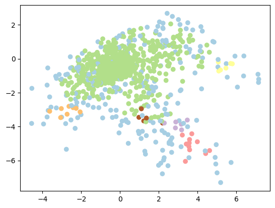

```python
plt.scatter(vectors[:,0], vectors[:,1],c = db_predicted_labels2, cmap='Paired')
plt.show ()
```

```python
homo_score2 = homogeneity_score (test_data_labels, db_predicted_labels2)
print (homo_score2)
```

```
0.05636463865577285
```

```python
sil_score2 = silhouette_score (vectors, db_predicted_labels2)
print (sil_score2)
```

```
0.18198313
```

### Questions

1- Problems: Clusters with fewer members may receive less attention from clustering algorithms and the model will have bias. Clustering algorithms may prioritize larger clusters and accuracy for smaller clusters will decrease. Algorithms might overlook smaller groups due to less samples, resulting in the loss of valuable information. Larger group can have more elements after predicting. </br> Solutions: Select or customize clustering algorithms that can handle imbalanced data - Request clustering algorithms to assign higher weights to samples from smaller groups - Generate new samples for minority groups through slight modifications, employing data augmentation techniques or deleting some samples from larger groups.

2- Stemming is a text normalization technique that involves removing suffixes from words to obtain their root form, known as the stem. This process aims to reduce words to a common base, even if the result is not a valid word. </br> Lemmatization is a more sophisticated approach where words are reduced to their base or root form, known as the lemma, using language dictionaries and morphological analysis. Lemmatization considers the context of the word and produces valid words.

3- A feature vector is a vector containing multiple elements about an object. They are good for analysis because there are many techniques for comparing feature vectors. One simple way to compare the feature vectors of two objects is to take the Euclidean distance.

4- Word2vec: Word2Vec is a group of machine learning architectures that can find words with similar contexts and group them together. When we say ‘context’, it refers to the group of words that surrounds a given word in a sentence or a document. The vectors representing words with similar meanings are positioned close to each other in this high-dimensional space. Word2Vec is a two-layer neural network that processes text by taking in batches of raw textual data, processing them and producing a vector space of several hundred dimensions. Each unique word in the data is assigned a corresponding vector in the space. The positioning of these vectors in the space is determined by the words’ semantic meanings and proximity to other words. </br> Doc2vec: The primary idea behind Doc2Vec is to associate a unique vector representation with each document in a corpus. This vector is learned during the model training process, similar to how Word2Vec learns word embeddings.

5- K-means: K-means is a centroid-based clustering algorithm, where we calculate the distance between each data point and a centroid to assign it to a cluster. The goal is to identify the K number of groups in the dataset. It is an iterative process of assigning each data point to the groups and slowly data points get clustered based on similar features. The objective is to minimize the sum of distances between the data points and the cluster centroid, to identify the correct group each data point should belong to. Advantages: Simple to implement - Scales to large data sets - Guarantees convergence - Easily adapts to new examples. Disadvantages: Choosing k manually - Easily adapts to new examples - Clustering data of varying sizes and density - Clustering outliers. </br> DBSCAN: DBSCAN (Density-Based Spatial Clustering of Applications with Noise) is a popular learning method utilized in model building and machine learning algorithms. This is a clustering method that is used in machine learning to separate clusters of high density from clusters of low density. DBSCAN creates a circle of epsilon radius around every data point and classifies them into Core point, Border point, and Noise. A data point is a Core point if the circle around it contains at least ‘minPoints’ number of points. If the number of points is less than minPoints, then it is classified as Border Point, and if there are no other data points around any data point within epsilon radius, then it treated as Noise. Advantages: Separating clusters of high density versus clusters of low density - Handling outlier. Disadvantages: It isn't good with clusters of similar density - It isn't good with high dimensionality data. </br>

6- Acording to results we get better clusters with k-means. Because the data has high density.

7- Principal Component Analysis (PCA) is a dimensionality reduction technique widely used in machine learning and data analysis. The goal of PCA is to transform high-dimensional data into a lower-dimensional representation while preserving the most important information. It achieves this by identifying and capturing the principal components of the data. </br> First it standardizes data then it analyzes the covariance matrix of the standardized data. The next step involves calculating the eigenvalues and corresponding eigenvectors of the covariance matrix. Eigenvectors are the directions of the new feature space, and eigenvalues represent the magnitude of the variance in each of those directions. It sorts the eigenvectors in descending order based on their corresponding eigenvalues and then it decides how many principal components to retain. It converts the original data onto the selected principal components to obtain new data.

8- Silhouette: The silhouette score is a metric used to assess the goodness of a clustering technique, indicating how well-separated the clusters are. It measures how similar an object is to its own cluster (cohesion) compared to other clusters (separation). The silhouette score ranges from -1 to 1, the higher value is better. </br> Homogeneity: Homogeneity is a metric used to evaluate the quality of clusters in a clustering algorithm. Specifically, it measures the extent to which all data points within a cluster belong to the same class or category. The values are between 0 and 1 and value that is closer to 1 is better.

9- Showed above.

10- We can use better pre processing and we can optimize parameters and also we can use better models than doc2vec.